# Fee_data_2020

Adrian D. Garcia

August 2022

# Intro

## Getting Started

```r
library(waffle) #Waffle graphs
library(tidyverse) #For Data Analysis
library(lubridate) #For working with dates
library(DT) #For visualizing tables
```

First, I pulled in the data from Morningstar Direct. (I combined it using “Combine_Files.r”). There were 61,577 rows and 133 columns. Data was pulled from Morningstar Direct on Aug. 24, 2022.

For the 2019 fee study from Morningstar the analyst says they used the lesser of Annual Report Net Expense Ratio and Annual Report Adjusted for each fund. “… adjusted excludes short interest, reverse repo rates, among other things that make it hard to compare fixed income and alt funds across firms. However, we didn’t JUST use adjusted because it’s not exhaustive of the whole universe we found – a handful of funds had missing adjusted expense ratios, but every one had a net expense ratio.”

```r
Full <- read_csv("data_combined.csv",
                 guess_max = 25000)
```

I made the following adjustments to the data:

- Replaced spaces in the column names with periods.
- Removed fund of funds & money funds
- Combined the following firms Eaton Vance & Calvert Research and Management, SPDR State Street Global Advisors & “State Street Global Advisors, Nuveen and TIAA Investments
- Calculated the average assets for 2019, 2020 and 2021.
- Multiplied the annual average asset figures by the expense ratio (to use later for asset-weighted calculations).
- Calculated the percent change in net expense ratios from 2019 to 2020 and 2020 to 2021.

```r
Adjusted_Data <- Full %>%
  rename_all(make.names) %>%
  filter(Fund.of..Funds != "Yes",
         US.Category.Group != "Money Market" | is.na(US.Category.Group),
         is.na(Obsolete..Date)
         ) %>%
  mutate(
    Firm.Name.Mod = case_when(
      Branding.Name == "iShares" ~ "BlackRock",
      Branding.Name == "SPDR State Street Global Advisors" ~ "State Street Global Advisors",
      Branding.Name == "Calvert Research and Management" ~ "Morgan Stanley",
      Branding.Name == "Eaton Vance" ~ "Morgan Stanley",
      Branding.Name == "Nuveen" ~ "TIAA Investments",
      Branding.Name %in% c("Harding Loevner", "Third Avenue", "Tweedy, Browner") ~ "AMG",
      Branding.Name %in% "Amundi" ~ "Pioneer Investments",
      grepl("AllianzGI", Name) ~ "AllianzGI_",
      TRUE ~ as.character(Firm.Name)
    )
  ) %>%
  mutate(
    Net_Asst_2019_AVG = rowMeans(.[, 73:84], na.rm = TRUE),
    Net_Asst_2020_AVG = rowMeans(.[, 85:96], na.rm = TRUE),
    Net_Asst_2021_AVG = rowMeans(.[, 97:108], na.rm = TRUE),
    Asst_By_Fee_2019 = Net_Asst_2019_AVG * Annual.Report.Adjusted.Expense.Ratio..Year2019,
    Asst_By_Fee_2020 = Net_Asst_2020_AVG * Annual.Report.Adjusted.Expense.Ratio..Year2020,
    Asst_By_Fee_2021 = Net_Asst_2021_AVG * Annual.Report.Adjusted.Expense.Ratio..Year2021,
    Pct_Change_2019_2020 = (
      Annual.Report.Adjusted.Expense.Ratio..Year2020 - Annual.Report.Adjusted.Expense.Ratio..Year2019
    ) / Annual.Report.Adjusted.Expense.Ratio..Year2019 * 100,
    Pct_Change_2020_2021 = (
      Annual.Report.Adjusted.Expense.Ratio..Year2021 - Annual.Report.Adjusted.Expense.Ratio..Year2020
    ) / Annual.Report.Adjusted.Expense.Ratio..Year2020 * 100
  )

write_csv(Adjusted_Data,
          "~/Data/Fee_Data_2022/fee_Data_2022/results/MF_Fee_Report_20220826_ag.csv")
```

# ACTIVE PRODUCTS

## Fund families with the lowest/highes fees across active products

Here I look at the fund families with the lowest and highest overall fees across active products. I filter out index funds and remove fees that are NA (blank) for 2021. 19,031 rows remain.

Additions:

- Group the data by firm
- Count how many shareclasses each firm has
- Sum their net assets 2021

Filter:

- Firms with at least 50 share classes
- Firms with at least $25 billion in assets in 2021

Next steps:

- Group the data by firm
- Count how many shareclasses each firm has
- Sum their adjusted assets (individually) for 2019, 2020 and 2021
- Sum their net assets (individually) for 2019, 2020 and 2021
- Divide the total adjusted assets by the total net asssets to calculate asset-weighted fees for each fund shop (individually) for 2019, 2020 and 2021

*48 rows **Active_Fees***

```r
ActiveFunds <- Adjusted_Data %>%
  filter(
    Net_Asst_2021_AVG != 0 &
      Index..Fund != "Yes" &
      !is.na(Annual.Report.Adjusted.Expense.Ratio..Year2021) &
      Investment.Type == "Open-End Fund"
    ) %>%
  group_by(Firm.Name.Mod) %>%
  mutate(
    Count = n(),
    Sum_Assets_2021 = sum(Net_Asst_2021_AVG, na.rm = TRUE)
  ) %>%
  ungroup() %>%
  filter(Count >= 50 &
           Sum_Assets_2021 >= 2.5e+10
         )

summaryinfo <- function(x) {
  summarise(x,
    Count = n(),
    Sum_Assts_Wted_2019 = sum(Asst_By_Fee_2019, na.rm = TRUE),
    Sum_Assets_2019 = sum(Net_Asst_2019_AVG, na.rm = TRUE),
    Fee_Wted_2019 = Sum_Assts_Wted_2019 / Sum_Assets_2019,
    Sum_Assts_Wted_2020 = sum(Asst_By_Fee_2020, na.rm = TRUE),
    Sum_Assets_2020 = sum(Net_Asst_2020_AVG, na.rm = TRUE),
    Fee_Wted_2020 = Sum_Assts_Wted_2020 / Sum_Assets_2020,
    Sum_Assts_Wted_2021 = sum(Asst_By_Fee_2021, na.rm = TRUE),
    Sum_Assets_2021 = sum(Net_Asst_2021_AVG, na.rm = TRUE),
   Fee_Wted_2021 = Sum_Assts_Wted_2021 / Sum_Assets_2021
  )
  }

Active_Fees <- ActiveFunds %>%
  group_by(Firm.Name.Mod) %>%
  summaryinfo()

write_csv(Active_Fees,
          "~/Data/Fee_Data_2022/fee_Data_2022/results/active/fees_activefunds_firm.csv")

Active_HighFees <- Active_Fees %>%
  arrange(desc(Fee_Wted_2021)) %>%
  top_n(10, Fee_Wted_2021)

Active_LowFees <- Active_Fees %>%
  arrange(Fee_Wted_2021) %>%
  top_n(-10, Fee_Wted_2021)
```

Here’s a look at some of the above data. Full results saved as **fees_activefunds_firm.csv** in **Results** folder.

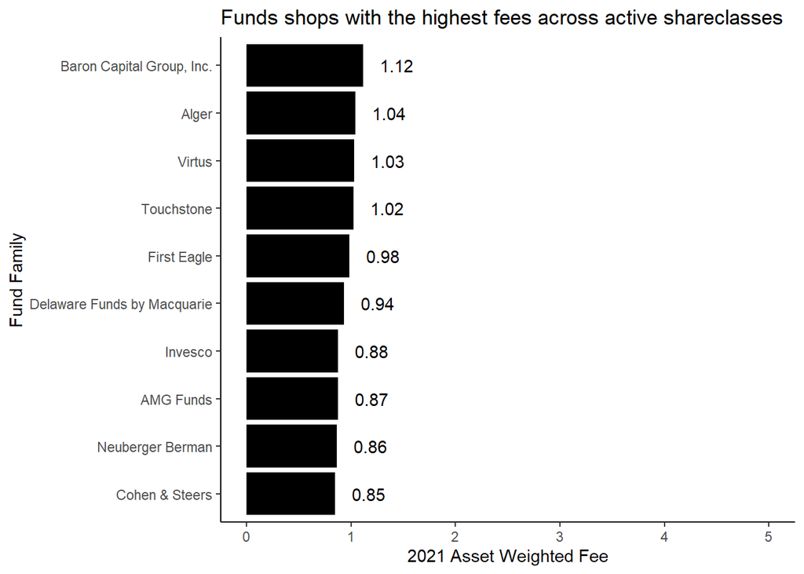

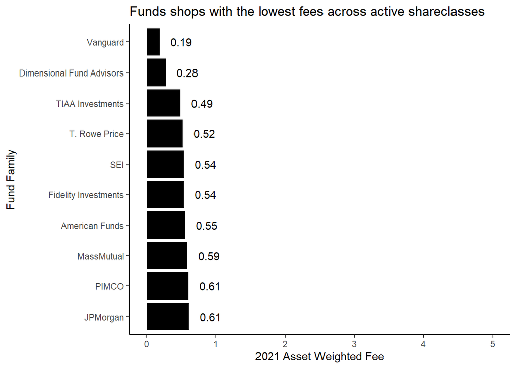

## Summary

Here I calculate the industry average net expense ratio, on an asset weighted basis for 2019, 2020 and 2021.

I take **ActiveFunds**

Next steps:

- Ungroup the data by firm
- Count how many shareclasses there are total
- Sum the adjusted assets (individually) for 2019, 2020 and 2021
- Sum their net assets (individually) for 2019, 2020 and 2021
- Divide the total adjusted assets by the total net asssets to calculate asset-weighted fees for each fund shop (individually) for 2019, 2020 and 2021

I drop the adjusted asset figures above and gather all the columns.

```r
Active_Summary <- ActiveFunds %>%
  ungroup() %>%
  summaryinfo() %>%
  select(
    1,
    3:4,
    6:7,
    9:10
  ) %>%
  gather(
    key = "Field",
    value, "Count",
    2:7
  )

write_csv(Active_Summary,
          "~/Data/Fee_Data_2022/fee_Data_2022/results/active/fees_activefunds_summary.csv")

datatable(Active_Summary)
```

|  | Field | value |
| --- | --- | --- |
| 1 | Count | 13676 |
| 2 | Sum_Assets_2019 | 9443435988416.44 |
| 3 | Fee_Wted_2019 | 0.627965133799263 |
| 4 | Sum_Assets_2020 | 9958069465622.35 |
| 5 | Fee_Wted_2020 | 0.60070579309945 |
| 6 | Sum_Assets_2021 | 12279767093150.3 |
| 7 | Fee_Wted_2021 | 0.584397135130805 |

## Fees by Type of Active Fund Category

Here I look at fund families’ fees for each U.S. category types for active funds. I pull in the filtered data from **ActiveFunds**.

Next steps:

- Group the data by firm and U.S. category group
- Sum their adjusted assets (individually) for 2019, 2020 and 2021
- Sum their net assets (individually) for 2019, 2020 and 2021
- Divide the total adjusted assets by the total net assets to calculate asset-weighted fees for each fund shop and category group (individually) for 2019 and 2020
- Count how many shareclasses there are for each category

Next:

- Group by firm name
- Sum total share classes for each fund family
- Sum total adjusted assets
- Sum total net assets
- Calculate average fee for each fund family
- Calculate percent of assets each fund family has in each category group

```r
Active_Cat <- ActiveFunds %>%
  group_by(Firm.Name.Mod, US.Category.Group) %>%
  summarise(
    Asst_Wted_Cat_2019 = sum(Asst_By_Fee_2019, na.rm = TRUE),
    Sum_Assets_Cat_2019 = sum(Net_Asst_2019_AVG, na.rm = TRUE),
    Fee_Wted_Cat_2019 = Asst_Wted_Cat_2019 / Sum_Assets_Cat_2019,
    Asst_Wted_Cat_2020 = sum(Asst_By_Fee_2020, na.rm = TRUE),
    Sum_Assets_Cat_2020 = sum(Net_Asst_2020_AVG, na.rm = TRUE),
    Fee_Wted_Cat_2020 = Asst_Wted_Cat_2020 / Sum_Assets_Cat_2020,
    Asst_Wted_Cat_2021 = sum(Asst_By_Fee_2021, na.rm = TRUE),
    Sum_Assets_Cat_2021 = sum(Net_Asst_2021_AVG, na.rm = TRUE),
    Fee_Wted_Cat_2021 = Asst_Wted_Cat_2021 / Sum_Assets_Cat_2021,
    Cat_Count = n()
  ) %>%
  group_by(Firm.Name.Mod) %>%
  mutate(
    ShareClass_Count = sum(Cat_Count, na.rm = TRUE),
    Sum_Assts_Wted_2020 = sum(Asst_Wted_Cat_2020, na.rm = TRUE),
    Sum_Assets_2020 = sum(Sum_Assets_Cat_2020, na.rm = TRUE),
    Fee_Wted_2020 = Sum_Assts_Wted_2020 / Sum_Assets_2020,
    pct_assets_2020 = (Sum_Assets_Cat_2020 / Sum_Assets_2020) * 100,
    Sum_Assts_Wted_2021 = sum(Asst_Wted_Cat_2021, na.rm = TRUE),
    Sum_Assets_2021 = sum(Sum_Assets_Cat_2021, na.rm = TRUE),
    Fee_Wted_2021 = Sum_Assts_Wted_2021 / Sum_Assets_2021,
    pct_assets_2021 = (Sum_Assets_Cat_2021 / Sum_Assets_2021) * 100
    )

write_csv(Active_Cat,
          "~/Data/Fee_Data_2022/fee_Data_2022/results/active/cat_activefunds_firm.csv")

Active_Cat_Sum <- Active_Cat %>%
  group_by(US.Category.Group) %>%
  summarise(
    SHARECLASSES = sum(Cat_Count),
    FEE = round((sum(Asst_Wted_Cat_2021)/sum(Sum_Assets_Cat_2021)),2),
    ASSETS = sum(Sum_Assets_Cat_2021)
    ) %>%
  mutate(
    pct = round(ASSETS / sum(ASSETS)*100,2)
    )

Lowcost_Active_Firms <- Active_LowFees$Firm.Name.Mod
Highcost_Active_Firms <- Active_HighFees$Firm.Name.Mod

Active_Cat_Pct <- Active_Cat %>%
  select(
    Firm.Name.Mod,
    US.Category.Group,
    Cat_Count,
    Sum_Assets_Cat_2021,
    Sum_Assets_2021,
    Fee_Wted_Cat_2021,
    Fee_Wted_2021,
    pct_assets_2021
  ) %>%
  mutate(Type =
           case_when(
             grepl("Equity", US.Category.Group) ~ "Equity",
             grepl("Bond", US.Category.Group) ~ "Bond",
             TRUE ~ "Other"
           )) %>%
  # filter(Firm.Name.Mod %in% Lowcost_Active_Firms |
  #          Firm.Name.Mod %in% Highcost_Active_Firms) %>%
  # group_by(Firm.Name.Mod) %>%
  arrange(-Fee_Wted_2021, .by_group = TRUE)

write_csv(Active_Cat_Pct,
          "~/Data/Fee_Data_2022/fee_Data_2022/results/active/cat_activefunds_highlow.csv")
```

Here’s a look at some of the above data. Full results saved as **cat_activefunds_firm.csv** in **Results** folder.

```r
#Building Waffle charts with https://rud.is/rpubs/building-waffle-charts.html

Active_Cat_Pct %>%
  filter(Firm.Name.Mod %in% Lowcost_Active_Firms) %>%
  mutate(
     Category_Code = case_when(
      US.Category.Group == "U.S. Equity" ~ 1,
      US.Category.Group == "International Equity" ~ 2,
      US.Category.Group == "Sector Equity" ~ 3,
      US.Category.Group == "Taxable Bond" ~ 4,
      US.Category.Group == "Municipal Bond" ~ 5,
      US.Category.Group == "Allocation" ~ 6,
      US.Category.Group == "Alternative" ~ 7,
      US.Category.Group == "Commodities" ~ 8,
      TRUE ~ 999999)
  ) %>%
  arrange(-Category_Code, .by_group = TRUE) %>%
  ungroup() %>%
  mutate(Firm.Name.Mod = str_wrap(Firm.Name.Mod, width = 10)) %>%
  ggplot(.,
         aes(fill = US.Category.Group, values = pct_assets_2021)) +
  geom_waffle(
    colour = "white",
    n_rows = 10,
    size = 0.33,
    flip = TRUE,
    make_proportional = TRUE
  ) +
  facet_wrap( ~ Firm.Name.Mod) +
  coord_equal() +
  theme_minimal() +
  theme_enhance_waffle() +
  labs(title = "Type of Holdings in Low Cost Active Funds",
       subtitle = "% of assets in each category type")

Active_Cat_Pct %>%
  filter(Firm.Name.Mod %in% Highcost_Active_Firms) %>%
  mutate(
     Category_Code = case_when(
      US.Category.Group == "U.S. Equity" ~ 1,
      US.Category.Group == "International Equity" ~ 2,
      US.Category.Group == "Sector Equity" ~ 3,
      US.Category.Group == "Taxable Bond" ~ 4,
      US.Category.Group == "Municipal Bond" ~ 5,
      US.Category.Group == "Allocation" ~ 6,
      US.Category.Group == "Alternative" ~ 7,
      US.Category.Group == "Commodities" ~ 8,
      TRUE ~ 999999)
  ) %>%
  arrange(-Category_Code, .by_group = TRUE) %>%
  ungroup() %>%
  mutate(Firm.Name.Mod = str_wrap(Firm.Name.Mod, width = 10)) %>%
  ggplot(.,
         aes(fill = US.Category.Group, values = pct_assets_2020)) +
  geom_waffle(
    colour = "white",
    n_rows = 10,
    size = 0.33,
    flip = TRUE,
    make_proportional = TRUE
  ) +
  facet_wrap( ~ Firm.Name.Mod) +
  coord_equal() +
  theme_minimal() +
  theme_enhance_waffle() +
  labs(title = "Type of Holdings in High Cost Active Funds",
       subtitle = "% of assets in each category type")
```

[output not shown]

## Fees by Type of Morningstar Fund Category (ACTIVE)

Here I am looking at fund families’ fees for each Morningsar category types for active funds. I start by pulling in the filtered data from **ActiveFunds**.

Next steps:

- Group the data by firm and Morningstar category group
- Sum their adjusted assets (individually) for 2019, 2020 and 2021
- Sum their net assets (individually) for 2019, 2020 and 2021
- Divide the total adjusted assets by the total net asssets to calculate asset-weighted fees for each fund shop and category group (individually) for 2019 and 2020
- Count how many shareclasses there are for each category

Next:

- Group by firm name
- Sum total share classes for each fund family
- Sum total adjusted assets
- Sum total net assets
- Calculate average fee for each fund family
- Calculate percent of assets each fund family has in each category group

```r
Active_MSCat <- ActiveFunds %>%
  group_by(Firm.Name.Mod, Morningstar.Category) %>%
  summarise(
    Asst_Wted_Cat_2020 = sum(Asst_By_Fee_2020, na.rm = TRUE),
    Sum_Assets_Cat_2020 = sum(Net_Asst_2020_AVG, na.rm = TRUE),
    Fee_Wted_Cat_2020 = Asst_Wted_Cat_2020 / Sum_Assets_Cat_2020,
    Asst_Wted_Cat_2021 = sum(Asst_By_Fee_2021, na.rm = TRUE),
    Sum_Assets_Cat_2021 = sum(Net_Asst_2021_AVG, na.rm = TRUE),
    Fee_Wted_Cat_2021 = Asst_Wted_Cat_2021 / Sum_Assets_Cat_2021,
    Cat_Count = n()
  ) %>%
  group_by(Firm.Name.Mod) %>%
  mutate(
    ShareClass_Count = sum(Cat_Count, na.rm = TRUE),
    Sum_Assts_Wted_2020 = sum(Asst_Wted_Cat_2020, na.rm = TRUE),
    Sum_Assets_2020 = sum(Sum_Assets_Cat_2020, na.rm = TRUE),
    Fee_Wted_2020 = Sum_Assts_Wted_2020 / Sum_Assets_2020,
    pct_assets_2020 = (Sum_Assets_Cat_2020 / Sum_Assets_2020) * 100,
    Sum_Assts_Wted_2021 = sum(Asst_Wted_Cat_2021, na.rm = TRUE),
    Sum_Assets_2021 = sum(Sum_Assets_Cat_2021, na.rm = TRUE),
    Fee_Wted_2021 = Sum_Assts_Wted_2021 / Sum_Assets_2021,
    pct_assets_2021 = (Sum_Assets_Cat_2021 / Sum_Assets_2021) * 100
  )

write_csv(Active_MSCat,
          "~/Data/Fee_Data_2022/fee_Data_2022/results/active/MScat_activefunds.csv")


Active_MSCat_Sum <- Active_MSCat %>%
  group_by(Morningstar.Category) %>%
  summarise(
    SHARECLASSES = sum(Cat_Count),
    FEE = round((sum(Asst_Wted_Cat_2021)/sum(Sum_Assets_Cat_2021)),2),
    ASSETS = sum(Sum_Assets_Cat_2021)
  ) %>%
  mutate(
    pct = round(ASSETS / sum(ASSETS)*100,2),
    RANK = rank(-FEE)
  )

Lowcost_Active_Firms <- Active_LowFees$Firm.Name.Mod
Highcost_Active_Firms <- Active_HighFees$Firm.Name.Mod

Active_MSCat_Pct <- Active_MSCat %>%
  select(
    Firm.Name.Mod,
    Morningstar.Category,
    Cat_Count,
    Sum_Assets_Cat_2021,
    Sum_Assets_2021,
    Fee_Wted_Cat_2021,
    Fee_Wted_2021,
    pct_assets_2021
  ) %>%
  filter(Firm.Name.Mod %in% Lowcost_Active_Firms |
           Firm.Name.Mod %in% Highcost_Active_Firms) %>%
  group_by(Firm.Name.Mod) %>%
  arrange(-Fee_Wted_2021, .by_group = TRUE)

write_csv(Active_MSCat_Pct,
          "~/Data/Fee_Data_2022/fee_Data_2022/results/active/MScat_activefunds_highlow.csv")
```

Here’s a look at some of the above data. Full results saved as **MScat_activefunds.csv** in **Results** folder.

|  | Morningstar.Category | SHARECLASSES | FEE | ASSETS | pct | RANK |
| --- | --- | --- | --- | --- | --- | --- |
| 1 | US Fund Allocation--15% to 30% Equity | 18 | 0.57 | 10474475131.25 | 0.09 | 66 |
| 2 | US Fund Allocation--30% to 50% Equity | 139 | 0.46 | 146243122257.417 | 1.19 | 79 |
| 3 | US Fund Allocation--50% to 70% Equity | 288 | 0.52 | 754235782557.25 | 6.14 | 71.5 |
| 4 | US Fund Allocation--70% to 85% Equity | 70 | 0.57 | 161800878001.667 | 1.32 | 66 |
| 5 | US Fund Allocation--85%+ Equity | 10 | 0.75 | 5469362130.66667 | 0.04 | 41.5 |
| 6 | US Fund Bank Loan | 185 | 0.75 | 73616421557.25 | 0.6 | 41.5 |
| 7 | US Fund China Region | 52 | 1.1 | 3605057673 | 0.03 | 7 |
| 8 | US Fund Commodities Broad Basket | 64 | 0.52 | 27459986785.1591 | 0.22 | 71.5 |
| 9 | US Fund Communications | 21 | 0.76 | 13873709177.75 | 0.11 | 39 |
| 10 | US Fund Consumer Cyclical | 10 | 0.77 | 7222228606.75 | 0.06 | 37 |

[output cut: 97 more lines]

## Fee changes among active share classes

Next I create a category (FeeChange) that puts the percent changes (continous) in buckets (categorical). After that I just count the buckets.

Filter:

- Firms with at least 50 share classes
- Firms with at least $25 billion in assets

```r
Active_Shareclass <- Adjusted_Data %>%
  filter(
    Annual.Report.Adjusted.Expense.Ratio..Year2020 != 0 &
      !is.na(Annual.Report.Adjusted.Expense.Ratio..Year2020) &
      !is.na(Annual.Report.Adjusted.Expense.Ratio..Year2021) &
      Index..Fund == "No" &
      Investment.Type == "Open-End Fund"
  ) %>%
  mutate(
    FeeChange =
      cut(
        Pct_Change_2020_2021,
        breaks = c(-Inf,-0.001, 0, Inf),
        labels = c("Cut", "No Change", "Hike"),
        include.lowest = TRUE,
        right = TRUE
      )
    )

Active_Summary_Shareclass <- Active_Shareclass %>%
  group_by(Firm.Name.Mod,
           FeeChange) %>%
  summarise(count = n(),
    Sum_Assets = sum(Net_Asst_2021_AVG, na.rm = TRUE)
    ) %>%
  group_by(Firm.Name.Mod) %>%
  mutate(
    total_assets = sum(Sum_Assets),
    assets_pct = Sum_Assets / total_assets * 100,
    total_count = sum(count),
    count_pct = count / total_count * 100
  ) %>%
  filter(total_count >= 50 &
           total_assets >= 2.5e+10
         )
write_csv(
  Active_Summary_Shareclass,
  "~/Data/Fee_Data_2022/fee_Data_2022/results/active/shareclass_changes_activefunds.csv"
  )
```

Here’s a look at some of the above data. Full results saved as **shareclass_changes_activefunds.csv** in **Results** folder.

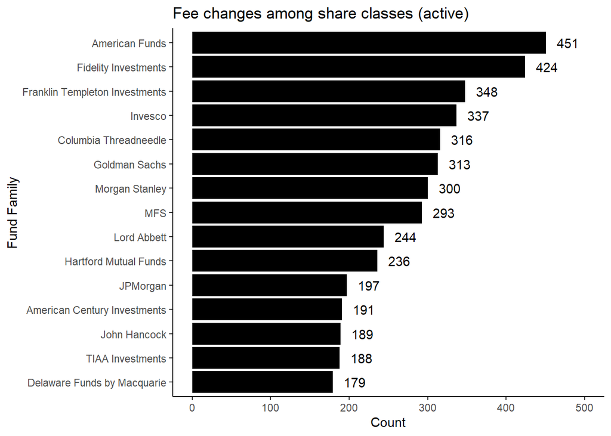

# PASSIVE

## Fund families with the lowest/highes fees across passive products

Here I look at the fund families with the lowest and highest overall fees across passive products. I start by filtering out non-index funds and removing fees that are NA (blank) for 2021. 1,046 rows remain.

Filter:

- Firms with at least 10 share classes
- Firms with at least $1 in assets

Next steps:

- Group the data by firm
- Sum their adjusted assets
- Sum their net assets
- Divide the total adjusted assets by the total net asssets to calculate asset-weighted fees for each fund shop.

*25 rows remain **PassiveFees***

```r
PassiveFunds <- Adjusted_Data %>%
  filter(
    Net_Asst_2021_AVG != 0 &
      Index..Fund != "No" &
      !is.na(Annual.Report.Adjusted.Expense.Ratio..Year2021) &
      Investment.Type == "Open-End Fund"
  ) %>%
  group_by(Firm.Name.Mod) %>%
  mutate(
    Count = n(),
    Sum_Assets_2021 = sum(Net_Asst_2021_AVG, na.rm = TRUE)
  ) %>%
  ungroup() %>%
  filter(Count >= 10,
         Sum_Assets_2021 > 0
         )

Passive_Fees <- PassiveFunds %>%
  group_by(Firm.Name.Mod) %>%
  summaryinfo()

# write_csv(Passive_Fees,
#           "fees_passivefunds_firm.csv")


Passive_HighFees <- Passive_Fees %>%
  arrange(desc(Fee_Wted_2021)) %>%
  top_n(10, Fee_Wted_2021)

Passive_LowFees <- Passive_Fees %>%
  arrange(Fee_Wted_2021) %>%
  top_n(-10, Fee_Wted_2021)
```

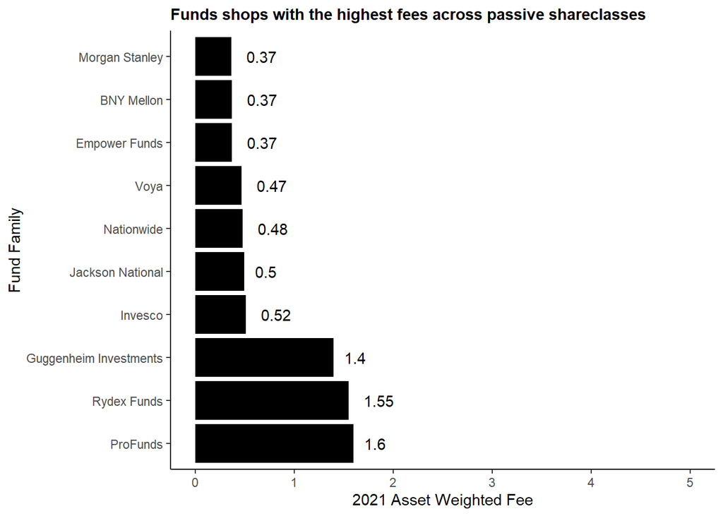

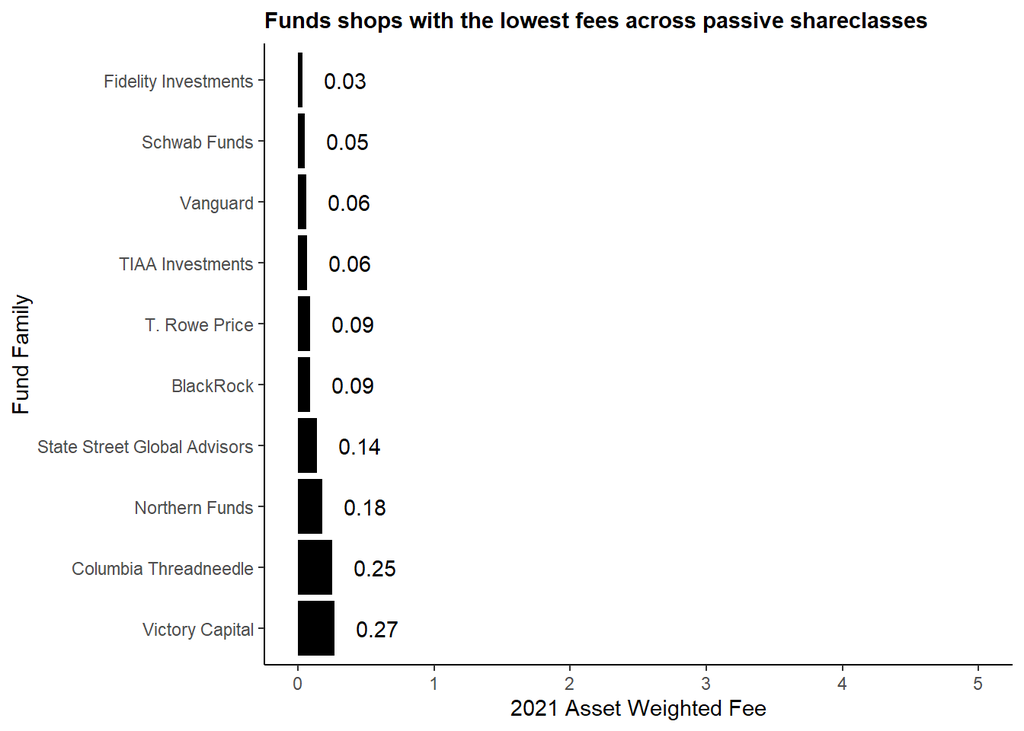

## Summary

Here I the average net expense ratio, on an asset weighted basis, for 2019, 2020 and 2021.

I take **PassiveFunds**

Next steps:

- Ungroup the data by firm
- Count how many shareclasses there are total
- Sum the adjusted assets (individually) for 2019, 2020 and 2021
- Sum their net assets (individually) for 2019, 2020 and 2021
- Divide the total adjusted assets by the total net asssets to calculate asset-weighted fees for each fund shop (individually) for 2019, 2020 and 2021

I drop the adjusted asset figures above and gather all the columns.

```r
Passive_Summary <- PassiveFunds %>%
  ungroup() %>%
  summaryinfo() %>%
  select(
    1,
    3:4,
    6:7,
    9:10
  ) %>%
  gather(
    key = "Field",
    value, "Count",
    2:7
  )

write_csv(Passive_Summary,
          "~/Data/Fee_Data_2022/fee_Data_2022/results/passive/fees_activefunds_summary.csv")

datatable(Passive_Summary)
```

|  | Field | value |
| --- | --- | --- |
| 1 | Count | 878 |
| 2 | Sum_Assets_2019 | 3539690762840.44 |
| 3 | Fee_Wted_2019 | 0.0785612233560644 |
| 4 | Sum_Assets_2020 | 3854049892340.6 |
| 5 | Fee_Wted_2020 | 0.0737275807196526 |
| 6 | Sum_Assets_2021 | 4897983781916.87 |
| 7 | Fee_Wted_2021 | 0.0707261506742452 |

## Past years

This does the same as **Fund families with the lowest/highes fees across passive products** except it includes 2019 figures as well.

```r
PassiveFunds_Past <- Adjusted_Data %>%
  filter(
    Net_Asst_2021_AVG != 0 &
      Index..Fund != "No" &
      !is.na(Annual.Report.Adjusted.Expense.Ratio..Year2020) &
      Investment.Type == "Open-End Fund"
  )

Passive_Fees_Past <- PassiveFunds_Past %>%
  group_by(Firm.Name.Mod) %>%
  summaryinfo() %>%
  filter(Count >= 10 &
           Sum_Assets_2021 > 0)

write_csv(
  Passive_Fees_Past,
  "~/Data/Fee_Data_2022/fee_Data_2022/results/passive/past_fees_passivefunds_firm.csv"
)


Passive_HighFees_Past <- Passive_Fees_Past %>%
  arrange(desc(Fee_Wted_2021)) %>%
  top_n(15)
Passive_LowFees_Past <- Passive_Fees_Past %>%
  arrange(Fee_Wted_2021) %>%
  top_n(-15)
Passive_LowFees_Past %>%
  select(1:4,
         6:7,
         5, 8) %>%

  write_csv("~/Data/Fee_Data_2022/fee_Data_2022/results/passive/past_lowfees_passivefunds_firm.csv")
```

## Fees by Type of Passive Fund Holdings

Here I am looking at fund families’ fees for each U.S. category types for passive funds. I start by pulling in the filtered data from **PassiveFunds**.

Next steps: * Group the data by firm and U.S. category group * Sum their adjusted assets * Sum their net assets * Divide the total adjusted assets by the total net asssets to calculate asset-weighted fees for each fund shop and category group. * Count how many shareclasses their are for each category

Next:

- Group by firm name
- Sum total share classes for each fund family
- Sum total adjusted assets
- Sum total net assets
- Calculate average fee for each fund family
- Calculate percent of assets each fund family has in each category group

Filter:

- Firms with at least 10 share classes
- Firms with at least $1 in assets

```r
Passive_Cat <- PassiveFunds %>%
  group_by(Firm.Name.Mod, US.Category.Group) %>%
  summarise(
    Asst_Wted_Cat = sum(Asst_By_Fee_2021, na.rm = TRUE),
    Sum_Assets_Cat = sum(Net_Asst_2021_AVG, na.rm = TRUE),
    Fee_Wted_Cat = Asst_Wted_Cat / Sum_Assets_Cat,
    Cat_Count = n()
  ) %>%
  group_by(Firm.Name.Mod) %>%
  mutate(
    ShareClass_Count = sum(Cat_Count, na.rm = TRUE),
    Sum_Assts_Wted = sum(Asst_Wted_Cat, na.rm = TRUE),
    Sum_Assets = sum(Sum_Assets_Cat, na.rm = TRUE),
    Fee_Wted = Sum_Assts_Wted / Sum_Assets,
    pct_assets = (Sum_Assets_Cat / Sum_Assets) * 100
    ) %>%
  filter(ShareClass_Count >= 10 &
           Sum_Assets > 0
         )

Passive_Cat_Sum <- Passive_Cat %>%
  group_by(US.Category.Group) %>%
  summarise(
    SHARECLASSES = sum(Cat_Count),
    FEE = (sum(Asst_Wted_Cat)/sum(Sum_Assets_Cat)),
    ASSETS = sum(Sum_Assets_Cat)
    ) %>%
  mutate(
    pct = round(ASSETS / sum(ASSETS)*100,2)
    )

Lowcost_Passive_Firms <- Passive_LowFees$Firm.Name.Mod

Passive_Cat_Pct <- Passive_Cat %>%
  select(Firm.Name.Mod, US.Category.Group,  Fee_Wted_Cat, pct_assets) %>%
  #spread(US.Category.Group, pct_assets) %>%
  # filter(
  #   Firm.Name.Mod %in% Lowcost_Passive_Firms
  #   ) %>%
  group_by(Firm.Name.Mod) %>%
  arrange(-pct_assets, .by_group = TRUE)

  write_csv(Passive_Cat_Pct, "~/Data/Fee_Data_2022/fee_Data_2022/results/passive/passivefunds_firm_category.csv")
```

```r
  ggplot(data = Passive_Cat_Pct,
         aes(fill = US.Category.Group, values = pct_assets)) +
  geom_waffle(colour = "white",
    n_rows = 10, size = 0.33,flip = TRUE, make_proportional = TRUE) +
    facet_wrap(~Firm.Name.Mod) +
  coord_equal() +
  theme_minimal() +
  theme_enhance_waffle() +
  labs(title = "Type of Holdings in Passive Funds",
       subtitle = "% of assets in each category type")
```

[output not shown]

```r
Passive_MSCat <- PassiveFunds %>%
  group_by(Firm.Name.Mod, Morningstar.Category) %>%
  summarise(
    Asst_Wted_Cat_2020 = sum(Asst_By_Fee_2020, na.rm = TRUE),
    Sum_Assets_Cat_2020 = sum(Net_Asst_2020_AVG, na.rm = TRUE),
    Fee_Wted_Cat_2020 = Asst_Wted_Cat_2020 / Sum_Assets_Cat_2020,
    Asst_Wted_Cat_2020 = sum(Asst_By_Fee_2020, na.rm = TRUE),
    Sum_Assets_Cat_2020 = sum(Net_Asst_2020_AVG, na.rm = TRUE),
    Fee_Wted_Cat_2020 = Asst_Wted_Cat_2020 / Sum_Assets_Cat_2020,
    Asst_Wted_Cat_2021 = sum(Asst_By_Fee_2021, na.rm = TRUE),
    Sum_Assets_Cat_2021 = sum(Net_Asst_2021_AVG, na.rm = TRUE),
    Fee_Wted_Cat_2021 = Asst_Wted_Cat_2021 / Sum_Assets_Cat_2021,
    Cat_Count = n()
  ) %>%
  group_by(Firm.Name.Mod) %>%
  mutate(
    ShareClass_Count = sum(Cat_Count, na.rm = TRUE),
    Sum_Assts_Wted_2020 = sum(Asst_Wted_Cat_2020, na.rm = TRUE),
    Sum_Assets_2020 = sum(Sum_Assets_Cat_2020, na.rm = TRUE),
    Fee_Wted_2020 = Sum_Assts_Wted_2020 / Sum_Assets_2020,
    pct_assets_2020 = (Sum_Assets_Cat_2020 / Sum_Assets_2020) * 100,
    Sum_Assts_Wted_2021 = sum(Asst_Wted_Cat_2021, na.rm = TRUE),
    Sum_Assets_2021 = sum(Sum_Assets_Cat_2021, na.rm = TRUE),
    Fee_Wted_2021 = Sum_Assts_Wted_2021 / Sum_Assets_2021,
    pct_assets_2021 = (Sum_Assets_Cat_2021 / Sum_Assets_2021) * 100
  )

write_csv(Passive_MSCat,
          "~/Data/Fee_Data_2022/fee_Data_2022/results/passive/MScat_passivefunds.csv")


Passive_MSCat_Sum <- Passive_MSCat %>%
  group_by(Morningstar.Category) %>%
  summarise(
    SHARECLASSES = sum(Cat_Count),
    FEE = round((sum(Asst_Wted_Cat_2021)/sum(Sum_Assets_Cat_2020)),2),
    ASSETS = sum(Sum_Assets_Cat_2021)
  ) %>%
  mutate(
    pct = round(ASSETS / sum(ASSETS)*100,2),
    RANK = rank(-FEE)
  )


Passive_MSCat_Pct <- Passive_MSCat %>%
  select(
    Firm.Name.Mod,
    Morningstar.Category,
    Cat_Count,
    Sum_Assets_Cat_2021,
    Sum_Assets_2021,
    Fee_Wted_Cat_2021,
    Fee_Wted_2021,
    pct_assets_2021
  ) %>%
  # filter(Firm.Name.Mod %in% Lowcost_Passive_Firms) %>%
  group_by(Firm.Name.Mod) %>%
  arrange(-Fee_Wted_2021, .by_group = TRUE)

write_csv(Passive_MSCat_Pct,
          "~/Data/Fee_Data_2022/fee_Data_2022/results/passive/MScat_passivefunds_highlow.csv")
```

## Fees by Share Class of Passive Fund Holdings

Here I am looking at fund families’ fees for each share class types for passive funds. It’s the same as above except with share class type instead of U.S. category group.

```r
Passive_shareclass_type <- PassiveFunds %>%
  group_by(Firm.Name.Mod, Share.Class.Type) %>%
  summarise(
    Asst_Wted_Cat = sum(Asst_By_Fee_2021, na.rm = TRUE),
    Sum_Assets_Cat = sum(Net_Asst_2021_AVG, na.rm = TRUE),
    Fee_Wted_Cat = Asst_Wted_Cat / Sum_Assets_Cat,
    Cat_Count = n()
  ) %>%
  group_by(Firm.Name.Mod) %>%
  mutate(
    ShareClass_Count = sum(Cat_Count, na.rm = TRUE),
    Sum_Assts_Wted = sum(Asst_Wted_Cat, na.rm = TRUE),
    Sum_Assets = sum(Sum_Assets_Cat, na.rm = TRUE),
    Fee_Wted = Sum_Assts_Wted / Sum_Assets,
    pct_assets = (Sum_Assets_Cat / Sum_Assets) * 100
    ) %>%
  filter(ShareClass_Count >= 10 &
           Sum_Assets > 0
         )

#Passive_shareclass_type_Pct <- Passive_Cat %>%
#  select(Firm.Name.Mod, Share.Class.Type, pct_assets) %>%
#   #spread(Share.Class.Type, pct_assets) %>%
#  filter(
#    Firm.Name.Mod %in% c("Fidelity Investments",
#                      "Schwab Funds",
#                      "Vanguard",
#                      "TIAA Investments",
#                      "BlackRock",
#                      "State Street Global Advisors",
#                      "Principal Funds",
#                      "Columbia",
#                      "Victory Capital",
#                      "Hartford Mutual Funds")
#     ) %>%
#   group_by(Firm.Name.Mod) %>%
#   arrange(-pct_assets, .by_group = TRUE)
```

## Fee changes among passive share classes

Next I created a category (FeeChange) that puts the percent changes (continous) in buckets (categorical). After that I just count the buckets.

Filter:

- Firms with at least 10 share classes
- Firms with at least $1 in assets

```r
Passive_Shareclass <- Adjusted_Data %>%
  filter(
    Annual.Report.Adjusted.Expense.Ratio..Year2020 != 0 &
      !is.na(Annual.Report.Adjusted.Expense.Ratio..Year2020) &
      !is.na(Annual.Report.Adjusted.Expense.Ratio..Year2021) &
      Index..Fund == "Yes" &
      Investment.Type == "Open-End Fund"
  ) %>%
  mutate(
    FeeChange =
      cut(
        Pct_Change_2020_2021,
        breaks = c(-Inf, -0.001, 0, Inf),
        labels = c("Cut", "No Change", "Hike"),
        include.lowest = TRUE,
        right = TRUE
      )
    )

Passive_Summary_Shareclass <- Passive_Shareclass %>%
  group_by(Firm.Name.Mod,
           FeeChange) %>%
  summarise(count = n(),
    Sum_Assets = sum(Net_Asst_2021_AVG, na.rm = TRUE),
    ) %>%
  group_by(Firm.Name.Mod) %>%
  mutate(
    total_assets = sum(Sum_Assets),
    assets_pct = Sum_Assets/total_assets * 100,
    total_count = sum(count),
    count_pct = count / total_count * 100
  ) %>%
  filter(
    total_count >= 10 &
      total_assets > 0
    )
write_csv(
  Passive_Summary_Shareclass,
  "~/Data/Fee_Data_2022/fee_Data_2022/results/passive/shareclass_changes_passivefunds.csv"
  )
```

Here’s a look at some of the above data. Full results saved as **shareclass_changes_passivefunds.csv** in **Results** folder.

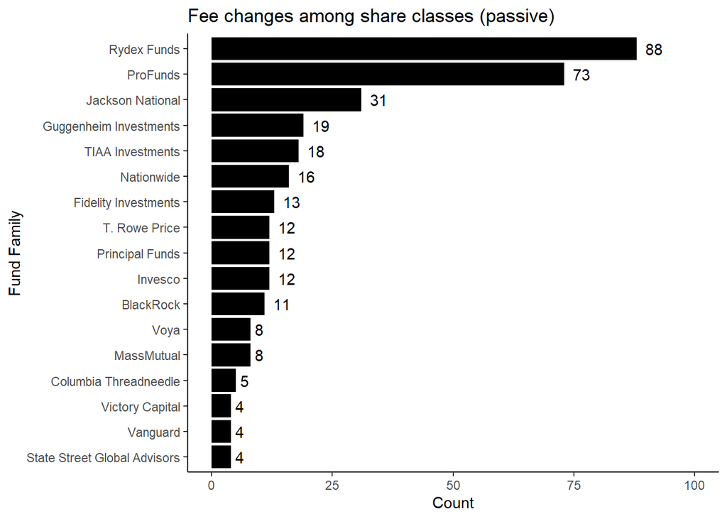

# General

## Fee changes among share classes (active & passive)

Here I am looking at how many share classes had fees that were cut and hiked or saw no change.

Next I create a category (FeeChange) that puts the percent changes (continuous) in buckets (categorical). After that I just count the buckets.

```r
Shareclass <- Adjusted_Data %>%
  filter(
    Annual.Report.Adjusted.Expense.Ratio..Year2020 != 0 &
      !is.na(Annual.Report.Adjusted.Expense.Ratio..Year2020) &
      !is.na(Annual.Report.Adjusted.Expense.Ratio..Year2021) &
      Investment.Type == "Open-End Fund"
  ) %>%
  mutate(
    FeeChange =
      cut(
        Pct_Change_2020_2021,
        breaks = c(-Inf,-0.001, 0, Inf),
        labels = c("Cut", "No Change", "Hike"),
        include.lowest = TRUE,
        right = TRUE)
    )

write_csv(Shareclass,
          "shareclass_fee_changes.csv"
          )

Summary_Shareclass <- Shareclass %>%
  group_by(Firm.Name.Mod,
           FeeChange,) %>%
  summarise(count = n()
            ) %>%
  group_by(Firm.Name.Mod
  ) %>%
  mutate(
    total_count = sum(count)
  )
```

Here’s a look at some of the above data. Full results saved as **shareclass_fee_changes.csv** in **Results** folder.

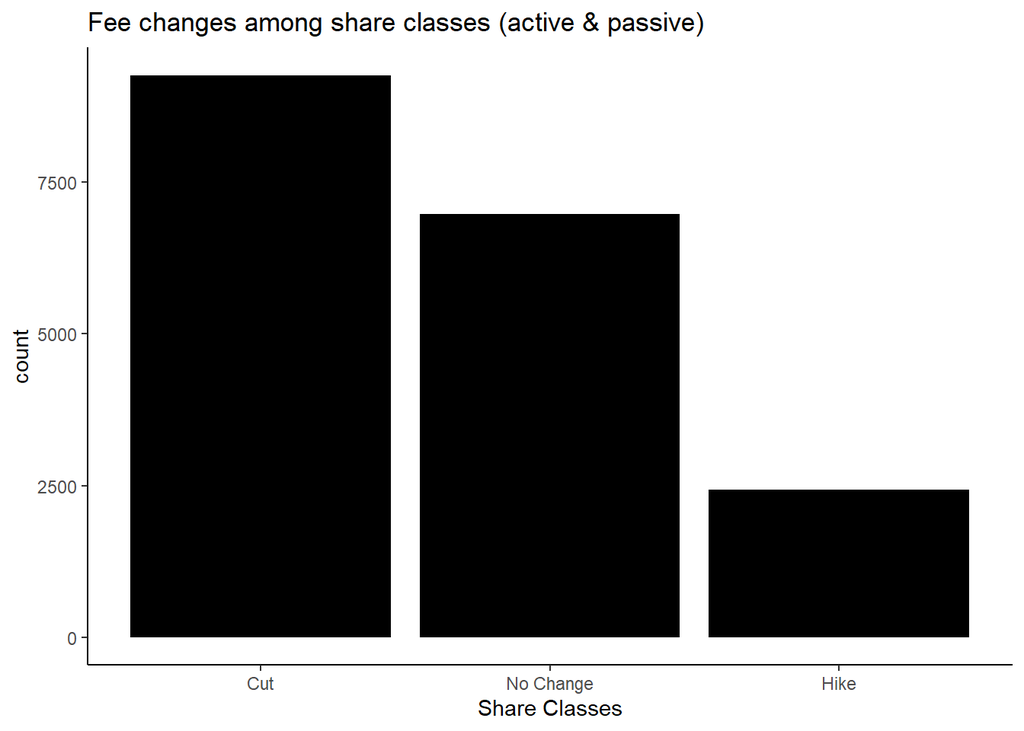

```r
Category <- Adjusted_Data %>%
  select(1:20,
         everything()) %>%
  filter(
    Annual.Report.Adjusted.Expense.Ratio..Year2020 != 0 &
      !is.na(Annual.Report.Adjusted.Expense.Ratio..Year2020) &
      !is.na(Annual.Report.Adjusted.Expense.Ratio..Year2021) &
      Investment.Type == "Open-End Fund"
  ) %>%
  mutate(
    FeeChange =
      cut(
        Pct_Change_2019_2020,
        breaks = c(-Inf, -50, -25, -10, -1, -0.01, 0, Inf),
        labels = c("< -50", "-25 - -50", "-10 - -25", "-1 - 10", "0 - -1", "0", "> 0"),
        include.lowest = TRUE,
        right = TRUE
      )
  )

write_csv(Category,
          "~/Data/Fee_Data_2022/fee_Data_2022/results/shareclass_cuts_total.csv")

Summary_Category <- Category %>%
  group_by(FeeChange) %>%
  summarise(count = n())

datatable(Summary_Category)
```

|  | FeeChange | count |
| --- | --- | --- |
| 1 | &lt; -50 | 44 |
| 2 | -25 - -50 | 124 |
| 3 | -10 - -25 | 578 |
| 4 | -1 - 10 | 4923 |
| 5 | 0 - -1 | 957 |
| 6 | 0 | 7207 |
| 7 | &gt; 0 | 4215 |
| 8 |  | 638 |

Here’s a look at the above data. Full results saved as **shareclass_cuts_total.csv** in **Results** folder.

[figure not shown]